# Moodle Group 1 Qs

Braden Baker

3/24/2021

## Question 1: How Long Does it Take for Students to View Their Feedback

Most students viewed their feedback within a couple days but every class had outliers where a student would not view their feedback for days. This data also does not include students that never checked their feedback.

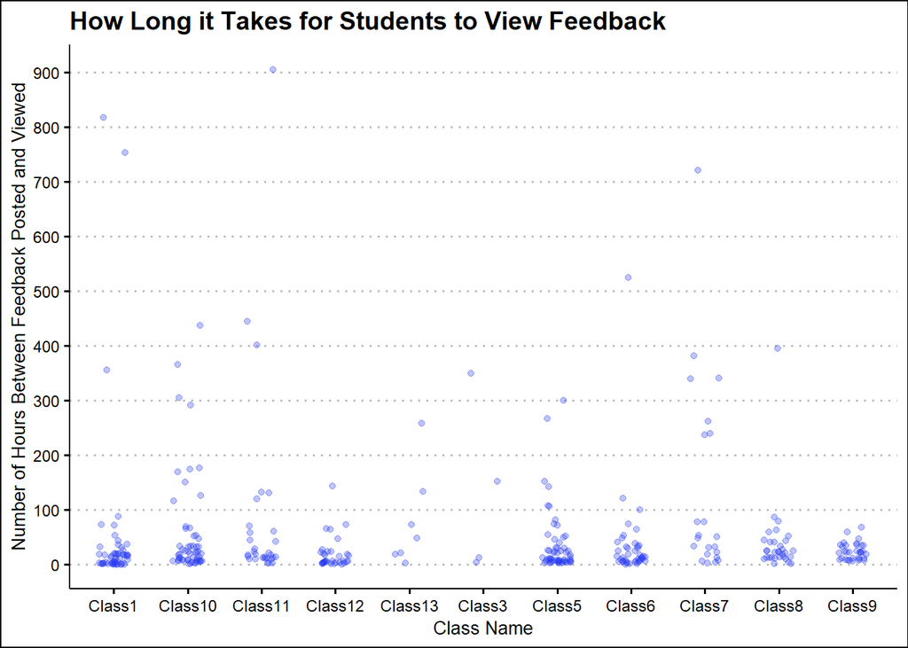

Despite the outliers, 80% of student feedback was viewed within about 50 hours from the time their feedback was posted.

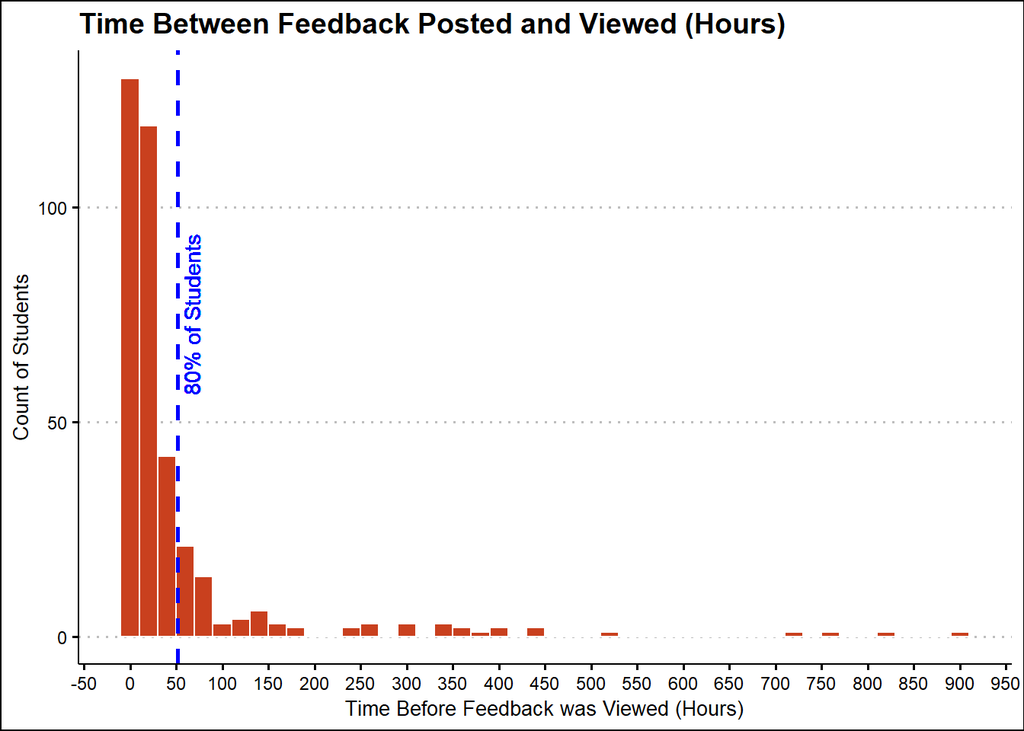

When including all classes, the median time to view feedback was 17.6 hours and the mean was 51.1 hours. Here it is best to focus on the median time to view feedback to lessen the impact of the outliers.

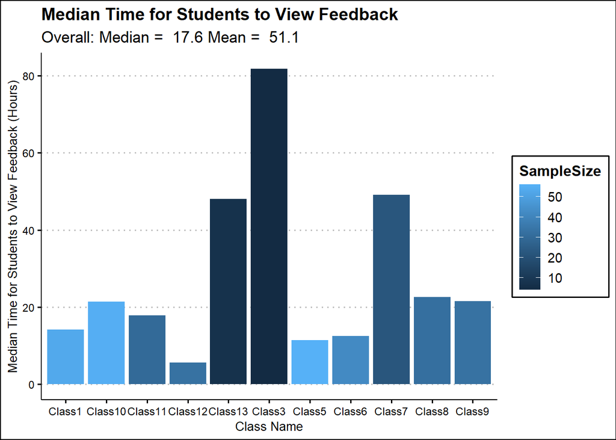

## Question 2: Which Moodle Resources get the Most and Least Number of Interactions

The assignment module type received the most views as expected. The next highest viewed were files which also had the highest number of modules added so its high view count is expected.

The viewership of URL is surprising since it had a large number of modules added. The other module types having low total viewership is expected given that there was less of those module types posted.

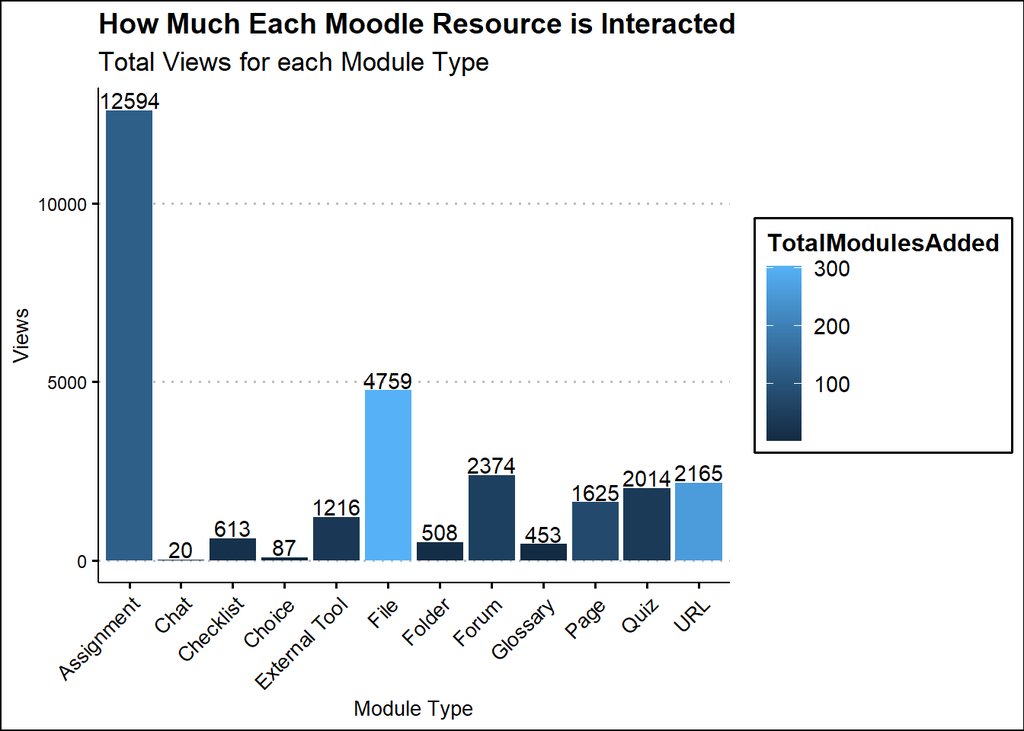

```
## # A tibble: 12 x 4
##    Moduletype    TotalModuleviews TotalModulesAdded ViewsPerModule
##  * <chr>                    <int>             <int>          <dbl>
##  1 Assignment               12594               128          98.4
##  2 Chat                        20                 1          20
##  3 Checklist                  613                16          38.3
##  4 Choice                      87                 1          87
##  5 External Tool             1216                35          34.7
##  6 File                      4759               304          15.7
##  7 Folder                     508                 9          56.4
##  8 Forum                     2374                55          43.2
##  9 Glossary                   453                 1         453
## 10 Page                      1625                79          20.6
## 11 Quiz                      2014                38          53
## 12 URL                       2165               261           8.30
```

When looking at views per module, glossary is clearly at the top. Only one glossary module was posted in the sample of logs but 450 views is very high and suggests it was used by students frequently. The choice model was similar, it was only used in one course but received quite a few views.

Forums also had an amount of views per module posted similar to quizzes suggesting that when forums are used, students are willing to interact with them as much as they do with another important module type.

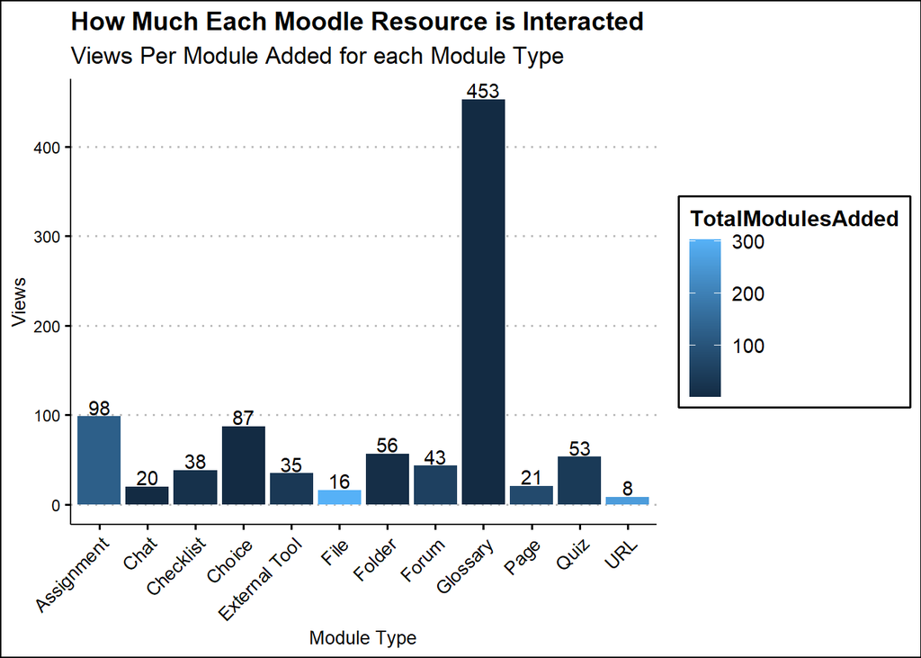

Students viewed most modules 1-2 times with the exception of assignments, choices, folders, and quizzes that were viewed 3-7 times.

File and URL module types were both viewed about 1 time per student. Most lecture materials are posted as those modules types so I would have expected them to have more viewership. Two possible reasons to explain this are that students could be returning to downloaded copies of files which would eliminate the need for to view the module again. Similarly they could be going directly to a URL instead of clicking on the module. The other possible reason could be that students are leaving files and URLs open until they are done working with them.

*How to read: The assignment module received an average of 103.5 views on each module posted, each student viewed an assignment module on average 6.7 times, and each class had an average of 9.8 assignment modules added*

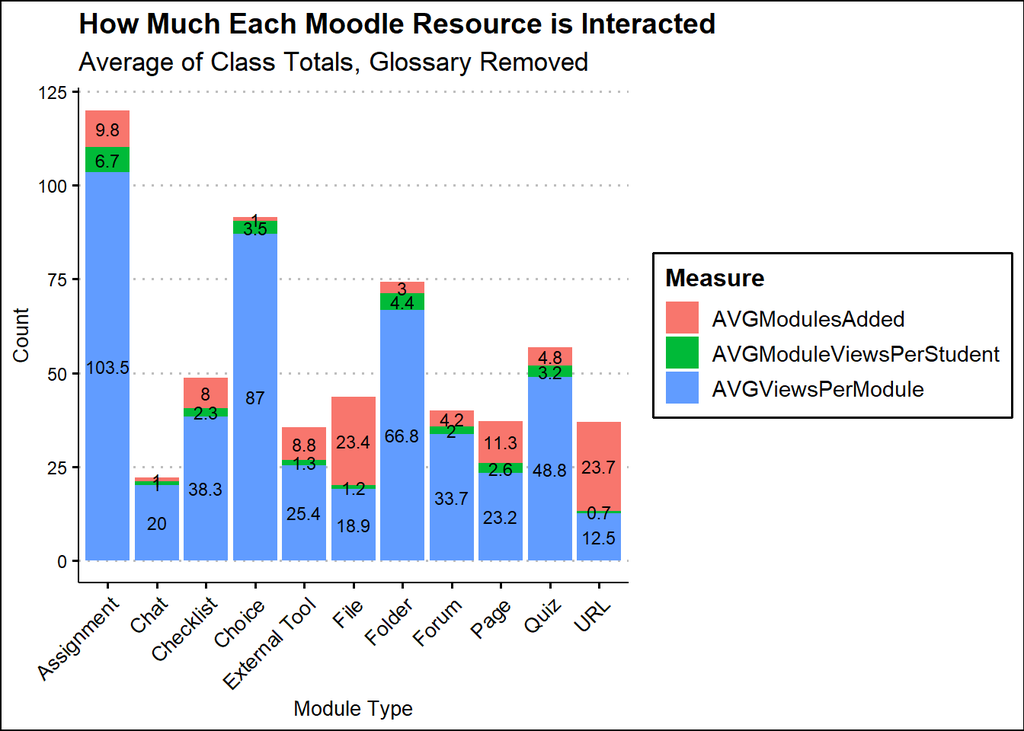

```
## # A tibble: 12 x 4
##    Moduletype    AVGModulesAdded AVGViewsPerModule AVGModuleViewsPerStudent
##    <chr>                   <dbl>             <dbl>                    <dbl>
##  1 Assignment               9.85             103.                     6.69
##  2 Chat                     1                 20                      1
##  3 Checklist                8                 38.3                    2.30
##  4 Choice                   1                 87                      3.48
##  5 External Tool            8.75              25.4                    1.34
##  6 File                    23.4               18.9                    1.20
##  7 Folder                   3                 66.8                    4.36
##  8 Forum                    4.23              33.7                    1.97
##  9 Glossary                 1                453                     19.7
## 10 Page                    11.3               23.2                    2.65
## 11 Quiz                     4.75              48.8                    3.22
## 12 URL                     23.7               12.5                    0.700
```

## How Often are Students Viewing Recorded Lectures?

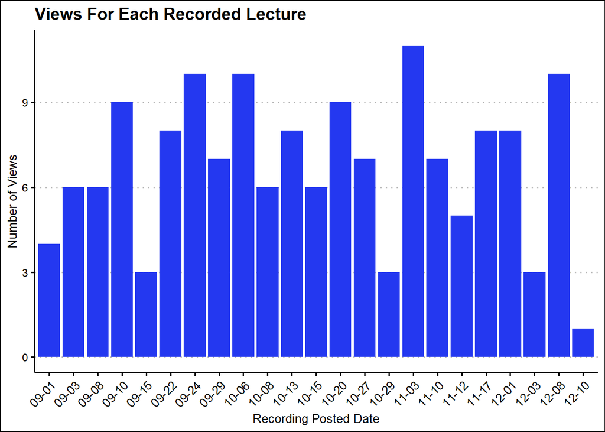

Most students viewed a recorded lecture within about 5 days of a recording being posted. However another decently sized group viewed recorded lectures 13+ days after the recording was posted.

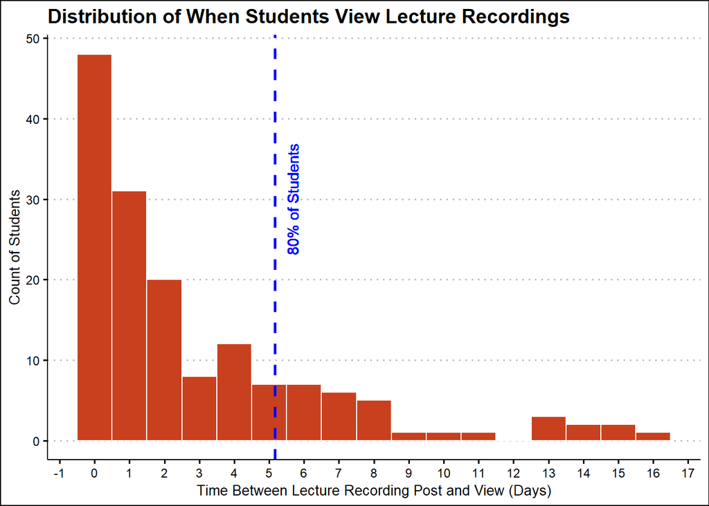

Examining further, it does seem that there may be two groups of views for recording lectures. One group views a few days after a recording is posted likely for homework, missing the class, or just going over it again. A second group views the recorded lecture days after it was posted likely for test preparation. This trend is strongest in November. Most November lectures received more views than other months 5+ days after the lecture was posted suggesting that the views may have been for preparing for end of semester exams or finals.

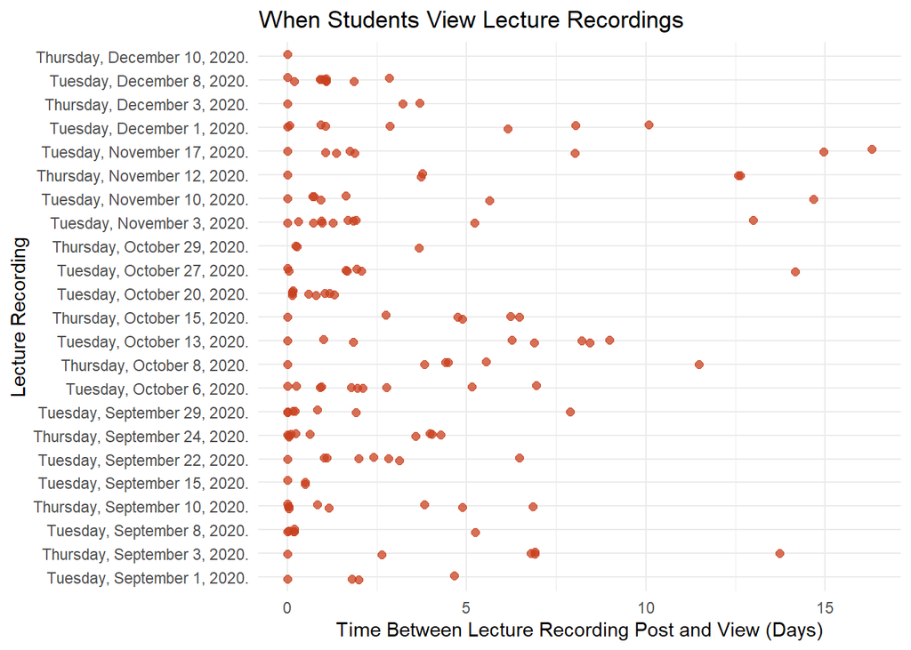